# EDA n Analysis

## 3. Which Factors Matter Most in Designing Attrition Reduction Strategies

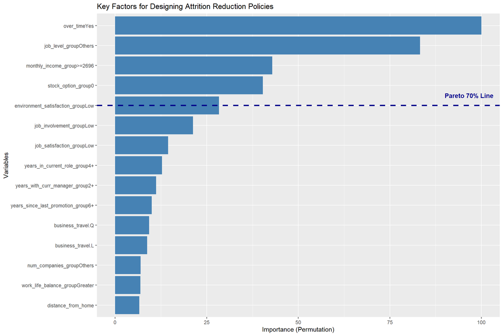

The chart above illustrates the importance of various factors in predicting employee attrition, as analyzed using a **Random Forest** model. This step aims to highlight the key areas that should be prioritized when developing strategies to reduce employee turnover.

The analysis reveals that **working overtime (over_timeYes)** is the most influential factor, indicating a strong correlation between frequent overtime and the likelihood of attrition. This suggests that prolonged job-related stress can lead to burnout and ultimately drive employees to leave the organization.

Following that, **being in a non-mainstream job level group (job_level_groupOthers)** also shows a significant impact. Employees outside the common career progression framework may feel a lack of clear direction or recognition, increasing their risk of leaving.

Additionally, **not having stock options (stock_option_group0)** and **low satisfaction with the work environment (environment_satisfaction_groupLow)** also rank high in importance. These findings highlight the role of financial incentives and emotional engagement in employee retention.

Overall, the most critical factors influencing attrition can be grouped into three key categories:

1. **Working conditions** – including overtime and the physical or emotional work environment.
2. **Compensation and benefits** – such as salary level and stock options.
3. **Personal perceptions and experiences** – including job involvement, satisfaction, and perceived career trajectory.

This analysis provides a data-driven foundation for developing targeted employee retention strategies. However, since the findings are based on a public reference dataset (IBM HR Analytics Dataset on Kaggle), they should be interpreted with caution. The practical implementation of any recommendations should be adjusted to fit the specific organizational context and operational constraints.